# Exercise #3 Survival Analysis Exercise

*DA6233 Kilger*

Name: *Dan Schumacher*

#### Imports

```python
import pandas as pd
from lifelines import KaplanMeierFitter
import matplotlib.pyplot as plt
from IPython.display import IFrame
import seaborn as sns
from lifelines.statistics import logrank_test, multivariate_logrank_test
```

#### Load and Clean Data

```python
# read in
short_df = pd.read_csv('./data/short_survival_data.csv')

# drop column that was accidentally added with all NAs
short_df.drop(short_df.columns[-1], axis=1, inplace=True)

# rename Status column to represent the positive class
short_df.rename(columns={short_df.columns[-1]:'dead', 'survival time in days': 'days'}, inplace=True)

# let's look
short_df.head(16)
```

|  | subject | days | dead |
| --- | --- | --- | --- |
| 0 | A | 1 | 1 |
| 1 | B | 4 | 1 |
| 2 | C | 5 | 0 |
| 3 | D | 5 | 1 |
| 4 | E | 7 | 1 |
| 5 | F | 10 | 0 |
| 6 | G | 10 | 0 |
| 7 | H | 12 | 1 |
| 8 | I | 14 | 1 |
| 9 | J | 16 | 0 |

```python
# Second database needed
long_df = pd.read_csv('./data/long_events_data.csv')

#rename group column
long_df.rename(columns={'Group#':'Group'}, inplace=True)

# let's look
long_df.head()
```

|  | Group | time | event |
| --- | --- | --- | --- |
| 0 | 1 | 681 | 0 |
| 1 | 1 | 602 | 0 |
| 2 | 1 | 996 | 0 |
| 3 | 1 | 1162 | 0 |
| 4 | 1 | 833 | 0 |

## 1. You are analyzing a 16 day study of patients who have Krusty the Clown disease. Your data includes a subject ID, their survival time and a status. A status of 0 means they are alive while a status of 1 means they died of the disease.

### a. Construct a survival table similar to the one in the lecture for the data. You will show your work within the table – if there is some division like 1/5 then show that like 1/5=.2 and if there is some multiplication then show the numbers being multiplied and the result e.g. .1 * 4 =0.4

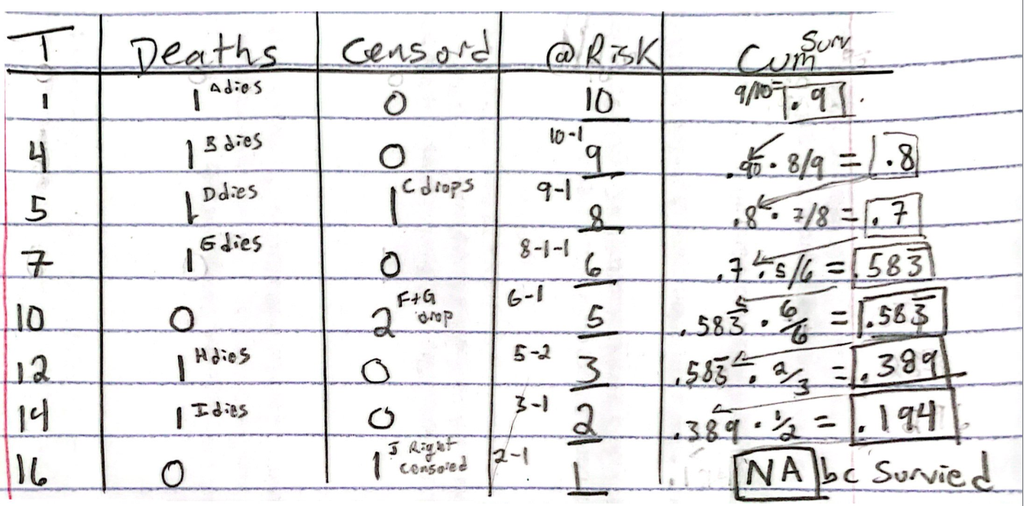

```python
from IPython.display import Image

# Display an image with its filename
Image(filename='./data/surv_an.png')
```

### b. Plot a survival curve for the probabilities you generate in part a.

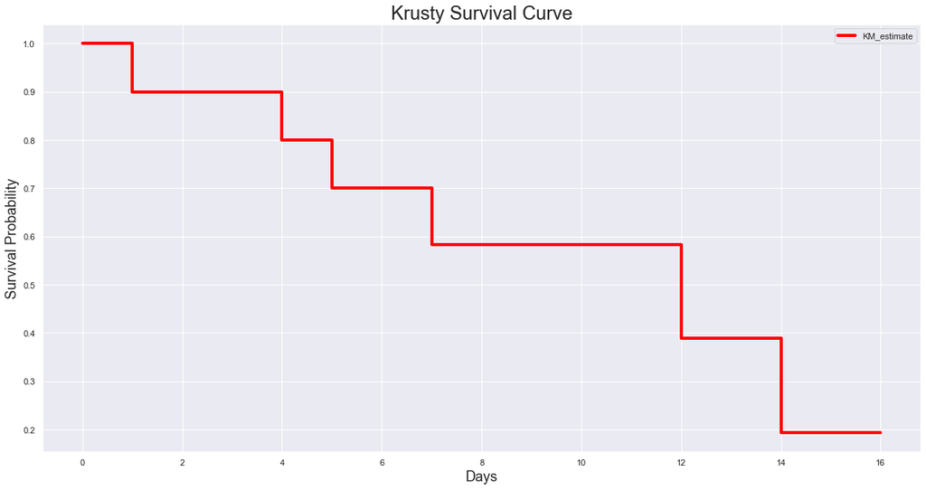

```python
#this looks better
sns.set(style="darkgrid")
plt.figure(figsize=(20,10))

# Instantiate
kmf = KaplanMeierFitter()

# Fit
kmf.fit(durations=short_df['days'], event_observed=short_df['dead'])

# Plot
kmf.plot_survival_function(ci_show=False, color='red', lw=4)
plt.title('Krusty Survival Curve', fontsize=24)
plt.xlabel('Days', fontsize=18)
plt.ylabel('Survival Probability',fontsize=18)
plt.show();
```